# STIN100 Datasett 2: Analyse av genuttrykk for å forstå effektene av gammastråling på gran

Benjamin Johan Madsen & Aksel Vardeberg Skeie

16 oktober 2018

## 1.4 Del 1: utforskning av data

## 1.4.1 Hvor mange rader (gener) og kolonner (prøver) har vi i tabellen?

```r
#Dette svarer på spørsmål 1

Antall_rader <- nrow(Aksel)
Antall_kolonner <- ncol(Aksel)
```

## 1.4.2 Skriv en kode som teller hvor mange replikater vi har per behandling (dvs stråledose) basert på kolonnenavnene?

```r
library(tidyr)
#Dette svarer på spørsmål 2
readCount <- colSums(Aksel[,-1])

d <- data.frame(navn = names(readCount),read = as.numeric(readCount))
d <- separate(d, navn, into=c('dosage', 'replicate'), sep= "-", remove = FALSE)

max(d$replicate, na.rm = TRUE)
```

```
## [1] "4"
```

## 1.4.3 Bruk ggplot() + geom_bar(stat=“identity”) til å visualisere antall RNAseq reads vi har sekvensert for hver prøve i hver behandling.

```r
#Dette svarer på spørsmål 3, readcount har ingen funksjon

readCount <- colSums(Aksel[,-1])
readCount
```

```
##     G0-1     G0-2     G0-3     G0-4     G1-1     G1-2     G1-3     G1-4
## 26750872 19258310 20478362 19467540 24809603 24517719 21976652 23852049
##    G10-1    G10-2    G10-3    G10-4    G40-1    G40-2    G40-3    G40-4
## 25667988 20295602 20577417 21388658 22265901 22018834 24982334 26225882
##   G100-1   G100-2   G100-3   G100-4
## 28643469 18751988 17912986 22822246
```

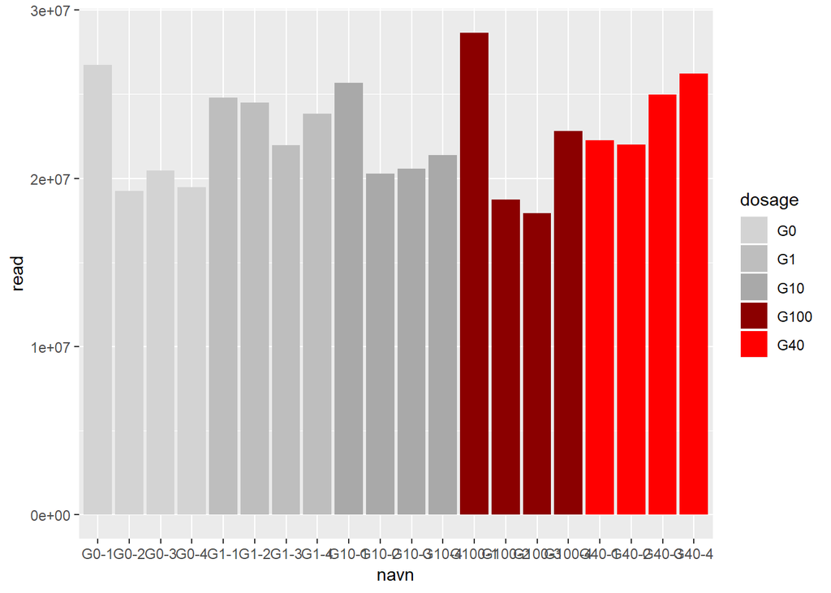

```r
samplecols = c(G0="lightgrey", G1="grey", G10="darkgrey", G40="red", G100="darkred")

library(ggplot2)
ggplot(d,aes(x=navn,y=read,fill = dosage)) + geom_bar(stat="identity") + scale_fill_manual(values = samplecols)
```

## 1.4.4 Hvor mange gener har 0 (dvs ikke målbart genuttrykk) i minst en behandling?

```r
#Dette svarer på spørsmål 4

library(dplyr)
Stack_col <- gather(data=Aksel, key= sample, value = uttrykk, -geneID) %>% group_by(geneID) %>% summarise(zeroTPM=  sum(uttrykk == 0))

mytable <- table(Stack_col$zeroTPM)

sum(mytable[2:21]) #Hvor mange gener har 0 (dvs ikke målbart genuttrykk) i minst en behandling?
```

```
## [1] 29673
```

## 1.4.5 Hvor mange gener har 0 i alle behandlinger?

```r
#Dette svarer på spørsmål 5

sum(mytable[21])#Hvor mange gener har 0 i alle behandlinger?
```

```
## [1] 8113
```

## 1.4.6 Hva slags biologiske tolkninger kan vi gjøre om gener vi ikke kan måle genuttrykket til?

Om gener der det finnes få eller ingen data på genets reads kan vi enten forstå det sånn at genet ikke blir påvirket av stråling eller ikke er skrudd på. Det kan også være at genmengden som ble sekvensert ikke var tilstrekkelig for å få en full lesning, og genet blir dermed regnet som ikke påvirket

## 1.5 Normalisering av genuttrykksdata for variable datamengder per prøve (antall reads)

## 1.5.1.1 Hva er det høyest målte genuttrykket vi har i tabellen med normaliserte data? (hvilket gen?)

```r
genuttrykkTPM <- readr::read_tsv("gene_expression_TPM.tsv")
library(tidyverse)
d.tidy <- genuttrykkTPM %>%
  as_tibble %>%
  gather(kolonne, tpm, -geneID) %>%
  separate(kolonne, sep = '-' , into = c("dose", "rep")) %>%
  mutate(dose = dose %>% str_sub(2) %>% as.numeric)

d.tidy[which.max(d.tidy$tpm),]
```

```
## # A tibble: 1 x 4
##   geneID          dose rep      tpm
##   <chr>          <dbl> <chr>  <dbl>
## 1 MA_183668g0010    10 4     34598.
```

Vi kan se her at *MA_183668g0010* er det høyest målete genutrykket.

## 1.5.2.1 Hva er gjennomsnittet/median av genuttrykk i tabellen?

```r
mean(d.tidy$tpm)
```

```
## [1] 15.13569
```

Dette er genomsnittsverdien av genuttrykk i tabellen.

## 1.5.3.1 Bruk geom_histogram til å visualisere fordelingen av genuttrykksnivå

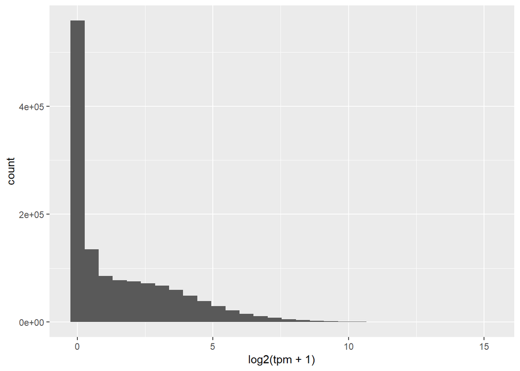

```r
library(ggplot2)

ggplot(d.tidy, aes(log2(tpm+1))) + geom_histogram()
```

```r
#legger til pluss en til alle veridene for å få med 0 veridene. På x-aksen ser man verdien kolonnen har mens på y aksen ser man antall celler i colonnen tpm som har den verdien. Ignorer bin-width
```

## 1.6 Del 2. Kvalitetskontroll av data

## 1.6.1 PCA

```r
#1. Transformer genutrykkTPM til en matris
genuttrykkTPM_matriks <- data.matrix(genuttrykkTPM[,-1], rownames.force = NA)

#2. Log transformer genutrykkTPM
genuttrykkTPM_matriks_log2 <- log2(genuttrykkTPM_matriks+1)

#3. Bruk "prcomp" og lagre resultatet som i object som heter "pca"
pca <- prcomp(t(genuttrykkTPM_matriks_log2))
pca$x
```

```
##                PC1        PC2         PC3        PC4         PC5
## G0-1   -30.3733968 -45.400100   7.5325878  -9.961967  10.5676763
## G0-2   105.7505873 -38.791875   8.3790982  41.705369  43.4931325
## G0-3   -23.2351813 -24.057706  21.7591863   2.379609  -6.9110821
## G0-4   -24.3327913 -28.853055  30.1424631  -7.706985 -11.3974298
## G1-1   -14.2562842 -14.301239  -2.4805169  -3.343830 -20.7620797
## G1-2   -21.9258156 -16.967224 -13.6180497 -11.531156 -22.1018010
## G1-3   -15.5905577 -45.414387  -8.4684045  16.049313 -10.0863267
## G1-4   -13.1588004 -31.628548 -14.5426623  -9.497620   2.2730311
## G10-1  -27.4479962 -31.959682  15.8560286  -4.317542  11.4694898
## G10-2   -1.8357508 -28.822595  11.2281165  -8.004331   7.1655831
## G10-3  163.4174074  22.325102  25.4763407 -23.931952 -31.7873042
## G10-4  -28.4693984  62.631752  29.8664552   1.819422  20.8798164
## G40-1  -24.6652685   3.482535  12.7209296  -3.073518  -9.7896969
## G40-2   17.8250150  26.404152 -49.6796053 -27.524799   7.9072233
## G40-3  -11.7138641  13.949543  -0.6037916 -20.199448   0.6905544
## G40-4   14.3275055   6.633292 -69.4142124 -15.470432  17.0408484
## G100-1   0.6409786  21.369931 -27.0666590  35.190696   1.5286210
## G100-2 -17.0144677  36.858391 -15.8654981  58.185641 -38.3814718
## G100-3 -19.1664532  52.266524  12.2016486 -13.889413   3.3010606
## G100-4 -28.7754676  60.275189  26.5765454   3.122944  24.9001555
##                PC6         PC7         PC8        PC9       PC10
## G0-1   -21.2653931  19.6706578 -27.8369633  -7.219998  13.004357
## G0-2    -4.3358023 -21.4465839   0.7716393  20.125584  -4.050237
## G0-3    -1.4879808 -24.9232852  22.5000801 -16.726893  17.772385
## G0-4    19.6544887 -17.5359643  -5.9063497  -3.965943  16.800796
## G1-1    -3.8510347  -0.6907124  28.5935307  12.621834 -12.077526
## G1-2   -26.5333260  -4.4715304  12.1859341  23.367758  -9.691755
## G1-3    -4.6651125   8.3486053   6.2155650  -2.336333 -13.834594
## G1-4    -7.8791680  25.1493756  -0.9871136   6.741982 -13.761008
## G10-1  -10.4013455   7.2580048 -18.4963013 -10.629709  10.395671
## G10-2   50.0512465   5.9540588  -1.7134062 -16.512743 -30.072931
## G10-3   -7.8356740  15.5877968  -3.0709599 -10.959552   3.827590
## G10-4  -13.4930864   3.9325306   9.3256087 -13.153577 -10.673805
## G40-1    0.7486443 -19.6158859   5.8171403   6.617917  15.848806
## G40-2    9.6663653 -24.8773525   1.7803481 -12.674151   2.331500
## G40-3   11.0756584   6.4532194  -4.2557533  16.586641  -4.723194
## G40-4   -9.2230231  -8.1146389  -5.1851973 -12.465730   4.038550
## G100-1  24.0278911  40.0224517  20.3358330   4.295178  31.436309
## G100-2  -3.6794744 -12.5065680 -28.3550484 -11.581430 -11.929474
```

[output cut: 29 more lines]

```
## G1-2   -15.56381792   1.2781687  -0.6922755   0.01698713  3.626606e-13
## G1-3    -7.77814594   5.2284054  -3.8337285  -0.71097996  1.632412e-13
## G1-4     9.78351933  36.0520361  -5.6035112  -0.17236811  1.576281e-13
## G10-1  -39.86317169  -8.7302447  -3.3983606   0.80168460 -9.353595e-14
## G10-2   -0.75764838  -4.2438836   5.2271709   0.85426772 -9.317254e-15
## G10-3   -1.58294223   1.4152806   1.8672751   0.30518281 -1.257266e-12
## G10-4   -0.08716591   0.9067221  -3.5552918 -24.55581443  1.718153e-13
## G40-1    8.55577641  15.6473821   3.4455628  -0.22097112  4.992849e-14
## G40-2   -0.12691453  -3.0132475 -27.4701578   3.67990037  1.480497e-13
## G40-3    9.05488873  -6.9649827   1.6484108   0.06390889  3.164258e-14
## G40-4   -1.75657398   0.4980249  26.4760081  -3.78112330  1.833941e-13
## G100-1  -3.88728619  -1.8676277  -2.7351506  -0.53287011  1.278637e-13
## G100-2   4.23774321  -0.7779751  -0.6671306   1.33028919  2.538371e-13
## G100-3  -3.63000323  -0.4180021   2.1028699  -0.31993747  3.159180e-13
## G100-4   0.31421182   2.3858155   4.6431290  23.88023008  2.343775e-13
```

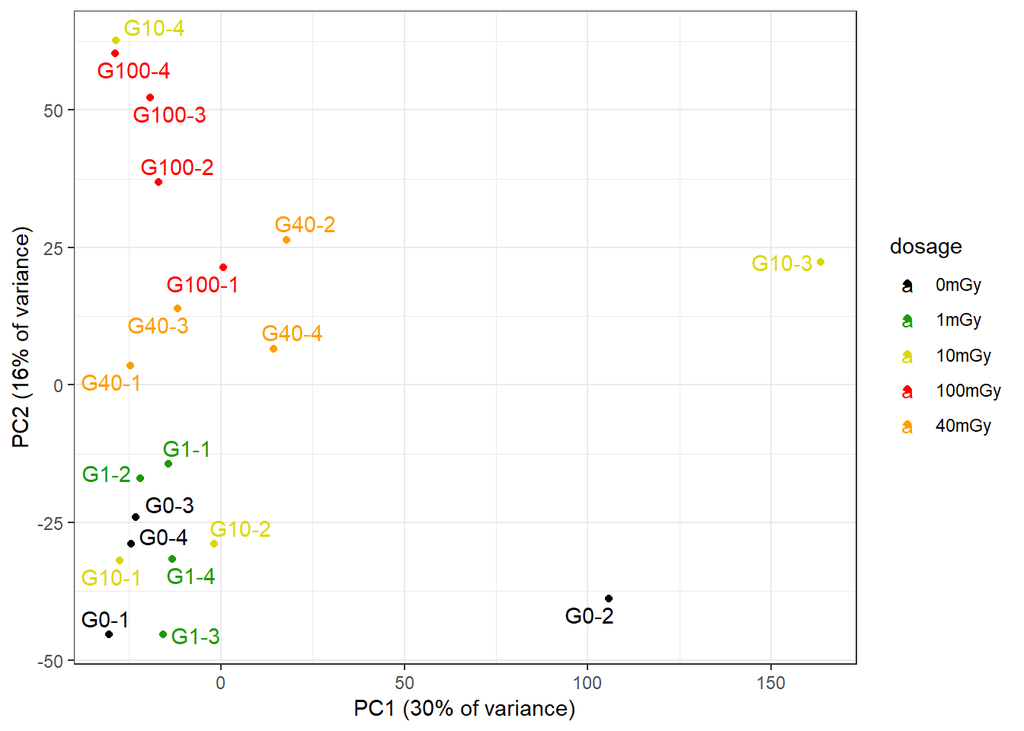

```r
percentVar <- pca$sdev^2/sum(pca$sdev^2)

library(tidyverse)
sampleMeta <-   tibble(sampleID = colnames(genuttrykkTPM)[-1]) %>%
  separate(sampleID, c("dosage", "replicate"), sep="-", remove = F) %>%
  mutate(dosage=factor(dosage, levels = unique(dosage)))

pcaTbl <-
  as_tibble(pca$x[,1:2]) %>%
  mutate(sampleID=rownames(pca$x)) %>%
  left_join(sampleMeta, by="sampleID")
write_tsv(pcaTbl,"pcaTbl.tsv")

pcaTbl <- read.table("pcaTbl.tsv", header = TRUE, check.names = FALSE, stringsAsFactors = FALSE)
radiationColor <- c(G0="#000000",G1="#1b9b07",G10="#dbd700",G40="#ff9d00",G100="#ff0000")
radiationLabels <- c(G0="0mGy",G1="1mGy",G10="10mGy",G40="40mGy",G100="100mGy")

library(ggrepel); library(ggplot2)
ggplot(pcaTbl, aes(x=PC1,y=PC2,color=dosage, label=sampleID)) +
  xlab(paste0('PC1 (', round(percentVar[1], 2)*100, '% of variance)')) +
  ylab(paste0('PC2 (', round(percentVar[2], 2)*100, '% of variance)')) +
  geom_point() +
  geom_text_repel() + # krever ggrepel pakken
  scale_color_manual(values = radiationColor,labels = radiationLabels) +
  theme_bw()
```

## 1.6.2 Klyngeanalyse med heatmap

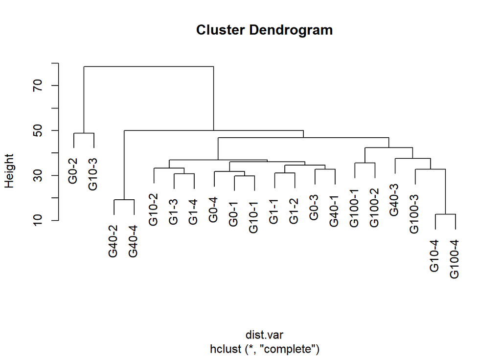

```r
library(dplyr)
library(tidyverse)
genuttrykk_varians <- genuttrykkTPM %>%
  gather(Sample, Uttrykk, -1) %>%
  group_by(geneID) %>%
  summarise(Varians = var(log(1+Uttrykk))) %>%
  arrange(desc(Varians)) %>%
  top_n(n = 5000, wt = Varians) -> genuttrykk_varians_5000

data.for.heatmap <- filter(genuttrykkTPM, geneID %in% genuttrykk_varians_5000$geneID) #Nå har vi endelig dataen vi skal jobbe med.

data.for.heatmap.matrix <- data.matrix(data.for.heatmap[,-1], rownames.force = NA) #Gjør det om til en matrix og fjerner kolonnen for geneID ettersom den er ikke numerisk

data.for.heatmap.matrix.log <- log(data.for.heatmap.matrix + 1) #Log transformer genutrykkTPM

data.for.heatmap.matrix.log.scaled <- scale(data.for.heatmap.matrix.log, center = TRUE, scale = TRUE) #skalerer det.

dist.var <- dist(t(data.for.heatmap.matrix.log.scaled)) #Beregn distanser mellom variablene etter skalering, dermed kan vi se vekk i fra korelasjon.

#likhetstre for kolonnene

dist.var.tre <- hclust(dist.var) #Vi kan visualisere likhetene i et tre.
plot(dist.var.tre) #plotter likheten med funksjonen "plot"
```

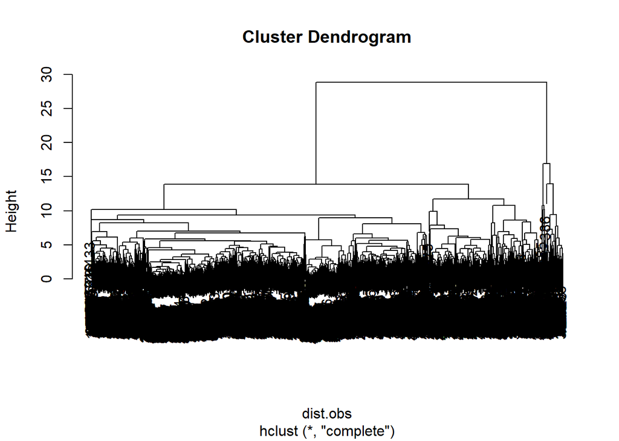

```r
#likhetstre for radene

dist.obs <- dist(data.for.heatmap.matrix.log.scaled)
dist.obs.tre <- hclust(dist.obs)
plot(dist.obs.tre) #Prøv å fjern navnene på radene.
```

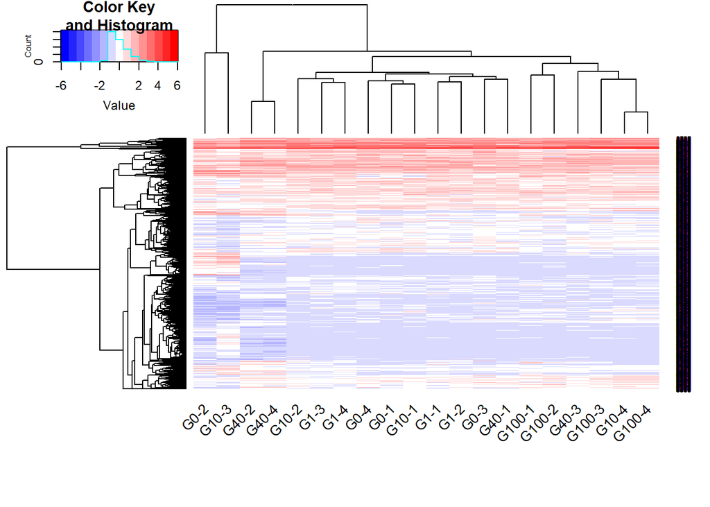

```r
#Sett sammen trærene for å lage et heat map

#install.packages("gplots")

library(gplots)
heatmap.2(x = data.for.heatmap.matrix.log.scaled,
          Rowv = as.dendrogram(dist.obs.tre),
          Colv = as.dendrogram(dist.var.tre),
          trace = "none",
          col = colorRampPalette(c("blue","white","red")),
          cexCol = 1,
          srtCol = 45,
          cexRow = 0.5,
          margins = c(7,3))
```